# Third Week: Exploratory Data Analysis

LaLiga Analysis

مهسا خوش نما 93101481

2018-02-28 02:26:00

# تمرین سری سوم: از لالیگا تا لیگ برتر

> با استفاده از داده های لیگ دسته اول اسپانیا به سوالات زیر پاسخ دهید. از هر دو ابزار ggplot2 و highcharter برای این کار تصویرسازی استفاده نمایید.

```r
library("dplyr")
library("highcharter")
library("ggplot2")
library(engsoccerdata)
library(ggthemes)
options(stringsAsFactors = FALSE)
```

۱. تعداد قهرمانی های تیم ها در تاریخ لالیگا را استخراج کرده و نمودار ستونی آنها را رسم کنید.

### پاسخ:

برای تشخیص قهرمان هر فصل، ابتدا امتیاز همه ی تیم ها در پایان فصل ها محاسبه کرده و سپس تیم با بیشترین امتیاز قهرمان محسوب می شود. اگر دو تیم با امتیاز برابر اول باشند نتیجه ی دو بازی رودرروی آن ها در لیگ، تعیین کننده خواهد بود. (هرکدام که مجموعا در بازی های رودررو گل بیشتری زده باشد)

```r
rbind(
  spain %>%
    select(Season, team = home, opp = visitor, GF = hgoal, GA = vgoal),
  spain %>%
    select(Season, team = visitor, opp = home, GF = vgoal, GA = hgoal)
) %>% mutate(GD = GF-GA) %>%
  group_by(team,Season) %>%
  summarize(GP = n(),
            goalsF = sum(GF),
            goalsA = sum(GA),
            goaldif = sum(GD),
            W = sum(GD>0),
            D = sum(GD==0),
            L = sum(GD<0)
  ) %>%
  mutate(score = W*3 + D) %>%
  arrange(Season,desc(score)) %>%
  group_by(Season) %>%
  mutate(rank = dense_rank(-score) %>% as.integer()) -> laliga1

laliga1 %>% filter(rank == 1) -> champions

#finding the years with ties
num_champions = champions %>% group_by(Season) %>% summarise(count = n()) %>% filter(count>=2)
for (year in num_champions$Season){
  teams = champions %>% filter(Season == year) %>% .$team
  s1 = spain %>% filter(Season == year & home == teams[1] & visitor == teams[2]) %>% .$hgoal +
    spain %>% filter(Season == year & home == teams[2] & visitor == teams[1]) %>% .$vgoal
  s2 = spain %>% filter(Season == year & home == teams[1] & visitor == teams[2]) %>% .$vgoal +
    spain %>% filter(Season == year & home == teams[2] & visitor == teams[1]) %>% .$hgoal
  if (s1>s2){
    champions[which(champions$Season == year & champions$team == teams[2]),"rank"] = 2
  }
  else if (s2>s1){
    champions[which(champions$Season == year & champions$team == teams[1]),"rank"] = 2
  }

}
champions = champions %>% filter(rank==1)
champions_count = champions %>% group_by(team) %>% summarise(count = n()) %>%
  arrange(desc(count))

#plots:
hchart(champions_count,type = "column",hcaes(x = team, y = count),
       name = "Championships") %>%  hc_add_theme(hc_theme_ffx())
```

[interactive chart not shown]

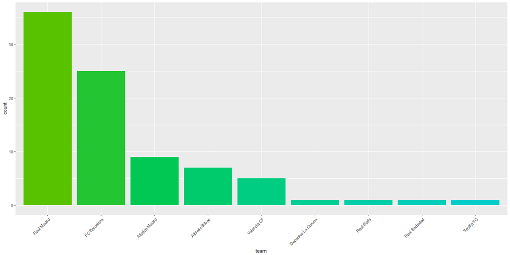

```r
ggplot(champions_count) + geom_bar(aes(x= reorder(team,-count),y = count ,
  fill = reorder(team,-count)), stat = "identity") +
  scale_fill_hue(h=c(120,190),l=70) +
  theme(axis.text.x = element_text(angle = 45, hjust = 1, vjust = 1),
  legend.position = "none") + xlab("team")
```

۲. کسل کننده ترین لیگ و تیم را بیابید. نمودار ده تیم و ده فصل کسل کننده را رسم کنید.

### پاسخ:

معیار کسل کنندگی را کمترین تعداد گل در نظر می گیریم. برای هر فصل ابتدا مجموع گل ها را حساب کرده سپس با تعداد بازی های فصل آن را نرمال میکنیم. 10 فصل با کمترین میانکین گل به ازای هر بازی را به عنوان کسل کننده ترین فصل ها در نظر می گیریم. کسل کننده ترین فصل هم فصل با کمترین میانگین گل در بازی در نظر می گیریم.

```r
boring_seasons = spain %>% group_by(Season) %>%
  summarise(goals = (sum(hgoal)+sum(vgoal))/(2*n())) %>%
  arrange(goals) %>% slice(1:10)

knitr::kable(boring_seasons[1,])
```

| Season | goals |
| --- | --- |
| 1972 | 1.071895 |

```r
hchart(boring_seasons,type = "bar",hcaes(x = reorder(Season,goals), y = goals,
                  color = reorder(Season,goals)),name = "Goals") %>%
  hc_add_theme(hc_theme_economist())
```

[interactive chart not shown]

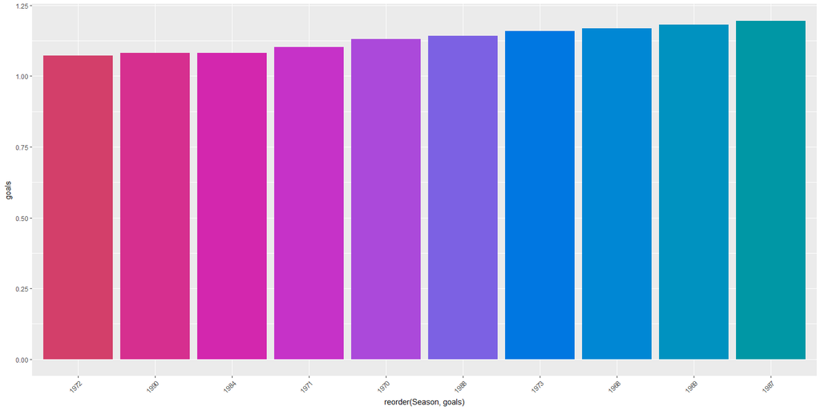

```r
ggplot(boring_seasons) + geom_bar(aes(x= reorder(Season,goals),y = goals ,
                          fill = reorder(Season,goals)), stat = "identity") +
  scale_fill_hue(h=c(360,200),l=50) + theme(axis.text.x = element_text(angle = 45, hjust = 1, vjust = 1),
                          legend.position = "none")
```

```r
boring_teams = laliga1 %>% group_by(team) %>% summarise(goals = sum(goalsF)/n()) %>%
  arrange(goals) %>% slice(1:10)

knitr::kable(boring_teams[1,])
```

| team | goals |
| --- | --- |
| Pontevedra CF | 27.5 |

```r
hchart(boring_teams,type = "bar",hcaes(x = team, y = goals,color = team),
       name = "Goal per Game") %>%  hc_add_theme(hc_theme_ft())
```

[interactive chart not shown]

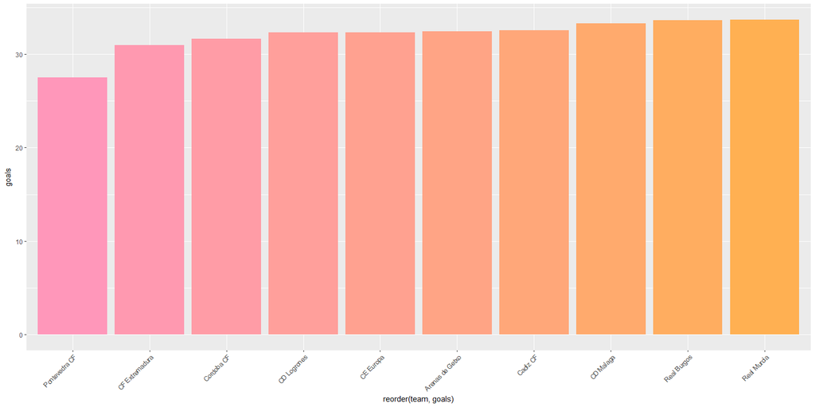

```r
ggplot(boring_teams) + geom_bar(aes(x= reorder(team,goals),y = goals ,
                                      fill = reorder(team,goals)), stat = "identity") +
  scale_fill_hue(h=c(0,40),l=80) + theme(axis.text.x = element_text(angle = 45, hjust = 1, vjust = 1),
                                            legend.position = "none")
```

۳. در چند درصد موارد قهرمان نیم فصل در پایان فصل قهرمان شده است؟

### پاسخ:

ابتدا بازی های هر فصل را بر حسب تاریخشان مرتب کرده و از این طریق امتیاز همه ی تیم ها را در نیم فصل محاسبه می کنیم. اگر دو تیم مشترکا بالاترین امتیاز را داشته باشند، ابتدا نتیجه ی دو بازی رودررویشان در لیگ را مقایسه می کنیم. اگر عملکردشان در این دو بازی یکسان باشد، اختلاف گلشان در طول نیم فصل را محاسبه می کنیم. اگر سه تیم مشترکا امتیاز اول را داشته باشند، در بازی های رودرروی دو به دویشان، اگر یکی از آن ها دو تیم دیگر را شکست داده باشد، قهرمان نیم فصل خواهد بود. پس از به دست آوردن قهرمان های نیم فصل نتیجه را با قهرمان های پایان فصل که در سوال 1 به دست آوردیم مقایسه می کنیم.

```r
rbind(
  spain %>%
    select(Season, Date, team = home, opp = visitor, GF = hgoal, GA = vgoal),
  spain %>%
    select(Season, Date, team = visitor, opp = home, GF = vgoal, GA = hgoal)
) %>% mutate(GD = GF-GA) %>%
  mutate(W = ifelse(GD > 0,1,0),
         D = ifelse(GD == 0,1,0),
         L = ifelse(GD < 0,1,0)
  ) %>% arrange(Season,team,Date) %>%
  group_by(Season,team) %>%
  mutate(play = row_number(Date)) %>% group_by(Season,team) %>%
  mutate(goalsF = cumsum(GF),
         goalsA = cumsum(GA),
         goaldif = cumsum(GD),
         Won = cumsum(W),
         Drawn = cumsum(D),
         Lost = cumsum(L)
  ) %>%
  mutate(score = Won*3 + Drawn) %>% arrange(Season,team,play) -> laliga2

half_champions = laliga2 %>% group_by(Season) %>% filter(play == max(play)/2) %>%
  group_by(Season) %>% mutate(rank = dense_rank(-score)) %>% filter(rank==1)

num_champions = half_champions %>% group_by(Season) %>% summarise(count = n()) %>% filter(count>=2)
#ties between 2 teams
for (year in num_champions$Season[which(num_champions$count==2)]){
  teams = half_champions %>% filter(Season == year) %>% .$team
  match = laliga2 %>% group_by(Season) %>% filter(play <= max(play)/2) %>%
    filter(Season == year & team == teams[1] & opp == teams[2])
  s1 = match$GF
  s2 = match$GA
  if (s1>s2){
    half_champions[which(half_champions$Season == year & half_champions$team == teams[2]),"rank"] = 2
  }
  else if (s2>s1){
    half_champions[which(half_champions$Season == year & half_champions$team == teams[1]),"rank"] = 2
  }
  else {
    d1 = half_champions %>% filter(Season == year & team == teams[1]) %>% .$goaldif
    d2 = half_champions %>% filter(Season == year & team == teams[2]) %>% .$goaldif
    if (d1>d2){
      half_champions[which(half_champions$Season == year & half_champions$team == teams[2]),"rank"] = 2
    }
    else if (d2>d1){
      half_champions[which(half_champions$Season == year & half_champions$team == teams[1]),"rank"] = 2
    }
  }

}
# ties between 3 teams
for (year in num_champions$Season[which(num_champions$count==3)]){
  teams = half_champions %>% filter(Season == year) %>% .$team
  match1 = laliga2 %>% group_by(Season) %>% filter(play <= max(play)/2) %>%
    filter(Season == year & team == teams[1] & opp == teams[2])
  match2 = laliga2 %>% group_by(Season) %>% filter(play <= max(play)/2) %>%
    filter(Season == year & team == teams[1] & opp == teams[3])
  match3 = laliga2 %>% group_by(Season) %>% filter(play <= max(play)/2) %>%
    filter(Season == year & team == teams[2] & opp == teams[3])
  s1 = match1$W*3 + match1$D + match2$W*3 + match2$D
  s2 = match1$L*3 + match1$D + match3$W*3 + match3$D
  s3 = match2$L*3 + match2$D + match3$L*3 + match3$D
  if (s1>s2 & s1>s3){
    half_champions[which(half_champions$Season == year &
              (half_champions$team == teams[2] | half_champions$team == teams[3])),"rank"] = 2
  }
  else if (s2>s1 & s2>s3){
    half_champions[which(half_champions$Season == year &
              (half_champions$team == teams[1] | half_champions$team == teams[3])),"rank"] = 2
  }
  else if (s3>s1 & s3>s2){
    half_champions[which(half_champions$Season == year &
              (half_champions$team == teams[1] | half_champions$team == teams[2])),"rank"] = 2
  }

}

half_champions = half_champions %>% filter(rank==1)
full_join(
  half_champions %>% select(Season, half_champion = team),
  champions %>% select(Season, champion = team)
) -> stat

percent = sum(stat$champion == stat$half_champion)/nrow(stat) *100
knitr::kable(percent)
```

| x |
| --- |
| 53.48837 |

همان طور که مشاهده می شود، 53.488 درصد فصل ها، قهرمان نیم فصل در پایان فصل قهرمان شده است.

۴. در بین سال های ۲۰۰۱ تا ۲۰۱۰ گربه سیاه تیم های بزرگ چه تیم هایی بوده است؟

### پاسخ:

ابتدا باید تیم های بزرگ در این 10سال را پیدا کنیم. به این منظور، تیم های اول تا سوم در طول این 10فصل را به دست آورده و تیم هایی که حداقل دو بار در این سی تیم ظاهر شده اند را به عنوان تیم بزرگ در نظر می گیریم. گربه سیاه این تیم ه را تیم هایی در نظر می گیریم که اولا از این تیم ها نباشند، ثانیا در طول این ده سال حداقل 18 امتیاز از این تیم ها گرفته باشند.

```r
##Big teams:
laliga1 %>% filter(Season>=2001 & Season<=2010 & rank<=3) %>%
  group_by(team) %>% summarise(count = n()) %>% arrange(-count) %>%
  filter(count>=2) %>% .$team -> big_teams

laliga1 %>% filter(Season>=2001 & Season<=2010 & rank<=3) %>%
  group_by(team) %>% summarise(count = n()) %>% arrange(-count) %>%
  filter(count>=2) %>% arrange(-count) %>%
  hchart(type = "column",hcaes(x = team, y = count),
        name = "bigness") %>%  hc_add_theme(hc_theme_ffx())
```

[interactive chart not shown]

```r
for (Team in big_teams){
  laliga2 %>% filter(Season>=2001 & Season<=2010 & opp == Team & !(team %in% big_teams)) %>%
    group_by(team) %>% summarise(points = sum(W*3 + D)) %>% filter(points>=18) %>%
    arrange(-points) -> black_cat
  print(sprintf("The black cats of %s are:",Team))
  print(black_cat)
}
```

```
## [1] "The black cats of Real Madrid are:"
## # A tibble: 1 x 2
##   team       points
##   <chr>       <dbl>
## 1 CA Osasuna   18.0
## [1] "The black cats of FC Barcelona are:"
## # A tibble: 1 x 2
##   team            points
##   <chr>            <dbl>
## 1 Atletico Madrid   25.0
## [1] "The black cats of Valencia CF are:"
## # A tibble: 5 x 2
##   team             points
##   <chr>             <dbl>
## 1 Racing Santander   30.0
## 2 Athletic Bilbao    21.0
## 3 Atletico Madrid    21.0
## 4 CA Osasuna         20.0
## 5 RCD Mallorca       19.0
## [1] "The black cats of Deportivo La Coruna are:"
## # A tibble: 7 x 2
##   team               points
##   <chr>               <dbl>
## 1 Atletico Madrid      34.0
## 2 Espanyol Barcelona   29.0
## 3 RCD Mallorca         29.0
## 4 CA Osasuna           24.0
## 5 Athletic Bilbao      22.0
## 6 Real Zaragoza        19.0
## 7 Racing Santander     18.0
## [1] "The black cats of Sevilla FC are:"
## # A tibble: 7 x 2
##   team               points
##   <chr>               <dbl>
## 1 CA Osasuna           27.0
## 2 Malaga CF            25.0
## 3 Getafe CF            24.0
## 4 Atletico Madrid      22.0
## 5 Espanyol Barcelona   21.0
## 6 Racing Santander     18.0
## 7 Real Zaragoza        18.0
## [1] "The black cats of Villarreal CF are:"
## # A tibble: 6 x 2
##   team               points
##   <chr>               <dbl>
## 1 CA Osasuna           27.0
## 2 Atletico Madrid      25.0
## 3 Real Betis           20.0
## 4 Espanyol Barcelona   18.0
## 5 Malaga CF            18.0
## 6 Real Zaragoza        18.0
```

امتیازهای نمایش داده شده در اطلاعات گربه سیاه ها تعداد امتیازهایی است که توانسته اند از تیم مقابلشان در این ده سال بگیرند.

۵. در تاریخ لالیگا کدام تیم رکورددار زودترین قهرمانی است؟ همچنین کدام تیم مقتدرانه ترین قهرمانی را داشته است؟

### پاسخ:

قهرمان زمانی قطعی می شود که اختلاف امتیازش با تیم دوم جدول از 3 برابر تعداد بازی های باقی مانده بیشتر باشد. در هر فصل بازی ای که در آن قهرمان قطعی شده را به دست آورده، آن را نسبت به تعداد کل بازی های هر تیم در فصل(تعداد هفته های فصل) نرمال کرده؛ در واقع بررسی می کنیم که قهرمانی در چه کسری از فصل قطعی شده و سپس زودترین قهرمانی را بر این اساس می یابیم.

```r
laliga2 %>% group_by(Season,play) %>% mutate(rank = row_number(-score)) ->laliga2
full_join(
   laliga2%>%
    filter(rank==1) %>% arrange(Season,play) %>% select(Season,play,team1 = team , score1 = score),
  laliga2 %>%
    filter(rank==2) %>% arrange(Season,play) %>% select(Season,play,team2 = team , score2 = score)
) %>% group_by(Season) %>% mutate(percent_play = play/max(play)) %>%
  filter((score1-score2)>3*(max(play)-play)) %>%
 group_by(Season) %>% slice(which.min(play)) -> stat

stat = stat[which(stat$percent_play == min(stat$percent_play)),]
knitr::kable(stat)
```

| Season | play | team1 | score1 | team2 | score2 | percent_play |
| --- | --- | --- | --- | --- | --- | --- |
| 1960 | 25 | Real Madrid | 68 | Atletico Madrid | 47 | 0.8333333 |
| 1962 | 25 | Real Madrid | 62 | Atletico Madrid | 45 | 0.8333333 |

برای به دست آوردن مقتدرانه ترین قهرمانیريا، اختلاف امتیاز تیم اول و دوم فصل را به دست آورده و با 3برابر تعداد بازی های هر تیم در لیگ یا به عبارتی ماکسیمم امتیاز ممکن برای هر تیم آن را نرمالیزه می کنیم. سپس بر اساس این معیار، مقتدرانه ترین قهرمانی را به دست می آوریم.

```r
full_join(
  laliga2 %>%
    filter(rank==1) %>% arrange(Season,play) %>% select(Season,play,team1 = team , score1 = score),
  laliga2 %>%
    filter(rank==2) %>% arrange(Season,play) %>% select(Season,play,team2 = team , score2 = score)
) %>% group_by(Season) %>% filter(play == max(play)) %>%
  mutate(score_diff_norm = (score1-score2)/(max(play)*3)) -> stat

stat = stat[which(stat$score_diff_norm == max(stat$score_diff_norm)),]
knitr::kable(stat)
```

| Season | play | team1 | score1 | team2 | score2 | score_diff_norm |
| --- | --- | --- | --- | --- | --- | --- |
| 1962 | 30 | Real Madrid | 72 | Atletico Madrid | 51 | 0.2333333 |

۶. طولانی ترین نوار پیروزی مساوی و شکست مال چه تیم هایی است؟

### پاسخ:

برای به دست آوردن طولانی ترین نوار شکست و پیروزی، برای هر تیم در هر بازی تعداد بردهایش تا آن بازی را and منطقی اش را با بردن در همان بازی به دست آورده، در این صورت برداری به دست می آوریم که در بازی هایی که متوالیا برده تعداد بردهایش تا کنون را داریم و سایر درایه ها که مربوط به تساوی ها یا باخت ها هستند صفر خواهد بود. حال برای به دست آوردن نوار های هرتیم باید درایه هایی از این بردار را که بلافاصله بعد ار آن ها صفر آمده یعنی نوار پیروزی قطع شده را به دست آورده و اختلافشان را حساب کنیم. برای هر تیم بلندترین نوارش را به دست آورده و سپس تیم با بلندترین نوار پیروزی را می یابیم. برای نوار شکست هم دقیقا به طرز مشابه عمل می کنیم.

```r
rbind(
  spain %>%
    select(Season, Date, team = home, opp = visitor, GF = hgoal, GA = vgoal),
  spain %>%
    select(Season, Date, team = visitor, opp = home, GF = vgoal, GA = hgoal)
) %>% mutate(GD = GF-GA) %>%
  mutate(W = ifelse(GD > 0,1,0),
         D = ifelse(GD == 0,1,0),
         L = ifelse(GD < 0,1,0)
  ) %>% arrange(team,Season,Date) %>%
  group_by(team) %>%
  mutate(play = row_number(Date)) %>% group_by(team) %>%
  mutate(
         Won = cumsum(W)*W,
         Lost = cumsum(L)*L
  ) %>%
  arrange(team,play) -> laliga3


W_tape = c()
L_tape = c()
for (t in unique(laliga3$team)) {
  won_tape = laliga3 %>% filter(team == t) %>% .$Won
  won_tape = unique(won_tape * as.numeric(!c(won_tape[-1],0))) %>% .[which(.>0)]
  won_tape = won_tape - c(0,won_tape[1:length(won_tape)-1])
  W_tape = c(W_tape,max(won_tape))
  lst_tape = laliga3 %>% filter(team == t) %>% .$Lost
  lst_tape = unique(lst_tape * as.numeric(!c(lst_tape[-1],0))) %>% .[which(.>0)]
  lst_tape = lst_tape - c(0,lst_tape[1:length(lst_tape)-1])
  L_tape = c(L_tape,max(lst_tape))
}

tape = data.frame(unique(laliga3$team),W_tape,L_tape)

knitr:: kable(tape[which(tape$W_tape == max(tape$W_tape)),1:2])
```

|  | unique.laliga3.team. | W_tape |
| --- | --- | --- |
| 29 | FC Barcelona | 16 |
| 43 | Real Madrid | 16 |

```r
knitr:: kable(tape[which(tape$L_tape == max(tape$L_tape)),c(1,3)])
```

|  | unique.laliga3.team. | L_tape |
| --- | --- | --- |
| 56 | UD Las Palmas | 11 |

۷. زودترین سقوط مال کدام تیم بوده است؟

### پاسخ:

با فرض این که در هر فصل، سه تیم حذف می شوند هر گاه فاصله ی تیم آخر با تیم چهارم، بیش از سه برابر تعداد بازی های باقی مانده باشد تیم آخر سقوطش قطعی می شود. بنابراین در هر فصل بازی ای که در آن سقوط آخرین تیم قطعی شده را به دست آورده، آن را نسبت به تعداد کل هفته های فصل نرمال کرده و سپس زوترین سقوط را با این معیار به دست می آوریم.

```r
laliga2 %>% group_by(Season,play) %>% mutate(rank = row_number(-score)) ->laliga2
full_join(
  laliga2%>% group_by(Season) %>%
    filter(rank==max(rank)-3) %>% arrange(Season,play) %>% select(Season,play,team1 = team , score1 = score),
  laliga2 %>% group_by(Season) %>%
    filter(rank==max(rank)) %>% arrange(Season,play) %>% select(Season,play,team2 = team , score2 = score)
) %>% group_by(Season) %>% mutate(percent_play = play/max(play)*100) %>%
  filter((score1-score2)>3*(max(play)-play)) %>%
  group_by(Season) %>% slice(which.min(play)) -> stat

stat = stat[which(stat$percent_play == min(stat$percent_play)),]
knitr:: kable(stat)
```

| Season | play | team1 | score1 | team2 | score2 | percent_play |
| --- | --- | --- | --- | --- | --- | --- |
| 1997 | 31 | UD Salamanca | 34 | Sporting Gijon | 9 | 81.57895 |